# Credit Card Default Prediction

Yi-Pei Chan

# Description

The dataset **Default** is taken from the ISLR package.

```r
dim(Default)
```

```
## [1] 10000     4
```

```r
head(Default,4)
```

|  | default | student | balance | income |
| --- | --- | --- | --- | --- |
| 1 | No | No | 729.5265 | 44361.63 |
| 2 | No | Yes | 817.1804 | 12106.13 |
| 3 | No | No | 1073.5492 | 31767.14 |
| 4 | No | No | 529.2506 | 35704.49 |

The below code constructs a training and testing set using a 70% (train) 30% (test) split.

```r
n.full <- nrow(Default)
n.full
```

```
## [1] 10000
```

```r
n.test <- floor(.3*n.full)
n.test
```

```
## [1] 3000
```

```r
set.seed(0) #use seed 0
test.index <- sample(1:n.full,n.test)
test.data <- Default[test.index,]
train.data <- Default[-test.index,]
n.train <- nrow(train.data)
n.train
```

```
## [1] 7000
```

```r
mean(train.data$student=="Yes" & train.data$default=="Yes")
```

```
## [1] 0.01357143
```

```r
mean(train.data$default=="Yes")
```

```
## [1] 0.03157143
```

```r
mean(test.data$student=="Yes" & test.data$default=="Yes")
```

```
## [1] 0.01066667
```

```r
mean(test.data$default=="Yes")
```

```
## [1] 0.03733333
```

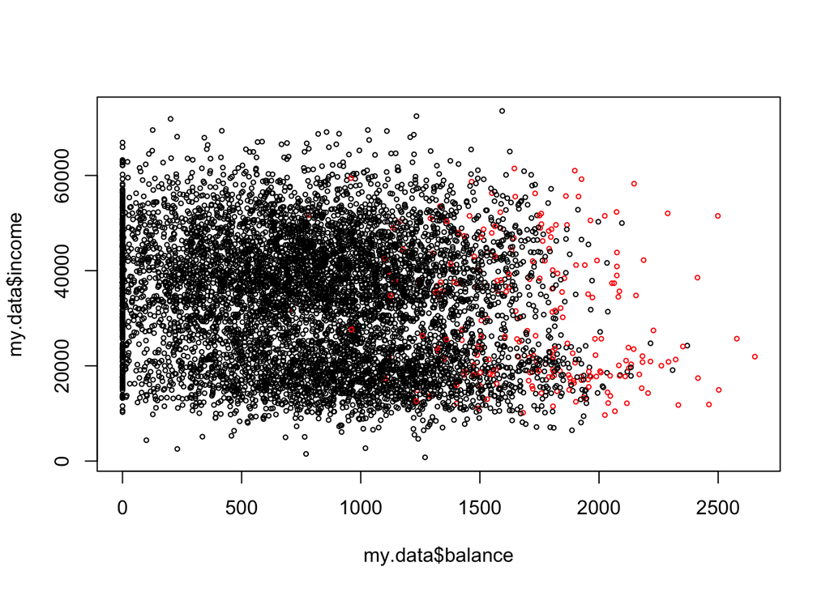

```r
my.data <- train.data[,c("balance","income")]
my.data$default <- ifelse(train.data$default=="Yes",1,0)
plot(my.data$balance,my.data$income,col=factor(my.data$default),cex=.5)
```

1. Fit the logistic regression model based on the training data. To train this model, regress **default** against the three features **student**, **balance**, and **income**. Also compute the training error and testing error for this model.

```r
train.data$default <- ifelse(train.data$default=="Yes",1,0)
test.data$default <- ifelse(test.data$default=="Yes",1,0)
glm.fit <- glm(default ~ student + balance + income, data = train.data, family = binomial)
#glm(default ~ student + balance + income, data = train.data, family = binomial("logit")) #same result as above
summary(glm.fit)
```

```
##
## Call:
## glm(formula = default ~ student + balance + income, family = binomial,
##     data = train.data)
##
## Deviance Residuals:
##     Min       1Q   Median       3Q      Max
## -2.1159  -0.1436  -0.0569  -0.0208   3.6714
##
## Coefficients:
##               Estimate Std. Error z value Pr(>|z|)
## (Intercept) -1.060e+01  5.928e-01 -17.885   <2e-16 ***
## studentYes  -6.026e-01  2.823e-01  -2.135   0.0328 *
## balance      5.651e-03  2.824e-04  20.012   <2e-16 ***
## income      -2.637e-06  9.922e-06  -0.266   0.7904
## ---
## Signif. codes:  0 '***' 0.001 '**' 0.01 '*' 0.05 '.' 0.1 ' ' 1
##
## (Dispersion parameter for binomial family taken to be 1)
##
##     Null deviance: 1962.3  on 6999  degrees of freedom
## Residual deviance: 1090.7  on 6996  degrees of freedom
## AIC: 1098.7
##
## Number of Fisher Scoring iterations: 8
```

```r
#### Method1 use confusion matrix
print("Method1 Use Confusion Matrix")
```

```
## [1] "Method1 Use Confusion Matrix"
```

```r
sigmoid <- function(u) {1/(1+exp(-u))}
y <-  train.data$default #; y
y.char <- factor(ifelse(y==1,"Y","N"))
y.hat.char <- ifelse(sigmoid(predict(glm.fit))>.5,"Y","N")
# if without using the sigmoid function then use:
# predict(glm_fit, type="response")
# it is the same as
# predict(model, type="response")[1:5] ==sigmoid(predict(model))[1:5]
# predict(model, type="response")[1:5] ==exp(predict(model)[1:5]) / (1+ exp(predict(model)[1:5]))
table(y.hat.char,y.char)
```

```
##           y.char
## y.hat.char    N    Y
##          N 6754  163
##          Y   25   58
```

```r
#Training error
mean(y.hat.char!=y.char)
```

```
## [1] 0.02685714
```

```r
# Confusion Matrix extraction
(table(y.hat.char,y.char)[1,2]+table(y.hat.char,y.char)[2,1])/sum(table(y.hat.char,y.char))
```

```
## [1] 0.02685714
```

```r
###Test error
y <-  test.data$default #; y
y.char <- factor(ifelse(y==1,"Y","N"))
y.hat.char <- ifelse(predict(glm.fit, newdata = test.data, type="response")>.5,"Y","N")
table(y.hat.char,y.char)
```

```
##           y.char
## y.hat.char    N    Y
##          N 2876   68
##          Y   12   44
```

```r
#Test error
mean(y.hat.char!=y.char)
```

```
## [1] 0.02666667
```

```r
# Confusion Matrix extraction
(table(y.hat.char,y.char)[1,2]+table(y.hat.char,y.char)[2,1])/sum(table(y.hat.char,y.char))
```

```
## [1] 0.02666667
```

```r
#### Method2 compute directly
print("Method2 Compute Directly")
```

```
## [1] "Method2 Compute Directly"
```

```r
train.data.new <- train.data %>% add_predictions(model = glm.fit, var = "pred") %>%
  mutate(sigmoid.pred = sigmoid(pred)) %>%mutate(glm.pred=ifelse(sigmoid.pred>0.5,1,0))
train.data.new <- as_tibble(train.data.new)


#training error
sum(train.data.new$default != train.data.new$glm.pred) / nrow(train.data.new)
```

```
## [1] 0.02685714
```

```r
#test error
test.data.new <- test.data %>% add_predictions(model = glm.fit, var = "pred") %>%
  mutate(sigmoid.pred = sigmoid(pred)) %>% mutate(glm.pred=ifelse(sigmoid.pred>0.5,1,0))
test.data.new <- as_tibble(test.data.new)
sum(test.data.new$default != test.data.new$glm.pred) / nrow(test.data.new)
```

```
## [1] 0.02666667
```

2. Write a function named **ROC.logistic()** that inputs the trained logistic model and an evaluation dataset (train or test). The function should output; i) ROC curve, AUC, and iii) the optimal threshold based on minimum 0-1 loss. Note in class we introduced Youden’s $J$ statistic but we will use the more common 0-1 loss.

See the class example for a more detained description.

```r
sigmoid <- function(u) {1/(1+exp(-u))}

ROC.logistic <- function(model, data){

  y <-  data$default
  y.char <- factor(ifelse(y==1,"Y","N"))


  y.hat <- predict(model,newdata=data[,c("balance","student","income")], type="response")
  # Define threshold vector
  prob.vec <- seq(0,1,by=.005)
  R <- length(prob.vec)

  # Define empty vectors for TP and FP rates
  true.pos <- rep(NA,R)
  false.pos <- rep(NA,R)

  error <- rep(NA,R)
  error.confusion <- rep(NA,R)

  # Loop
  # This loop computes TP and FP for each threshold
  # We are not required to estmiate multiple models, just the one lda()
  for (i in 1:R) {
    y.hat.char <- factor(ifelse(y.hat>prob.vec[i],"Y","N"),levels=c("N","Y"))

    # TP = P(Y.hat = 1 | Y = 1)
    true.pos[i] <- table(y.hat.char,y.char)[2,2]/sum(table(y.hat.char,y.char)[,2])

    # FP = P(Y.hat = 1 | Y = 0)
    false.pos[i] <- table(y.hat.char,y.char)[2,1]/sum(table(y.hat.char,y.char)[,1])

    #Test error
    error[i] <- mean(y.hat.char!=y.char)

    # Confusion Matrix extraction
    error.confusion[i] <- (table(y.hat.char,y.char)[1,2]+table(y.hat.char,y.char)[2,1])/sum(table(y.hat.char,y.char))
  }

  auc <- sum((true.pos[order(false.pos)][-1])*diff(false.pos[order(false.pos)]))

  {plot(false.pos,true.pos,type="l",col="blue",main="ROC: Model = Logistic Regression")
  abline(a=0,b=1,lty=3)}

  optimal.thres <- prob.vec[which(error == min(error))]
  #optimal.thres2 <- prob.vec[which(error.confusion == min(error.confusion))]

  cat("AUC:", auc,"\n")
  cat("The optimal threshold based on minimum 0-1 loss:", optimal.thres)#,"\n",optimal.thres2)
  return(tibble(auc = auc, optimal.thres = optimal.thres))

}
```

3. Run **ROC.logistic()** on both the training and testing data.

```r
cat("Train Data:")
```

```
## Train Data:
```

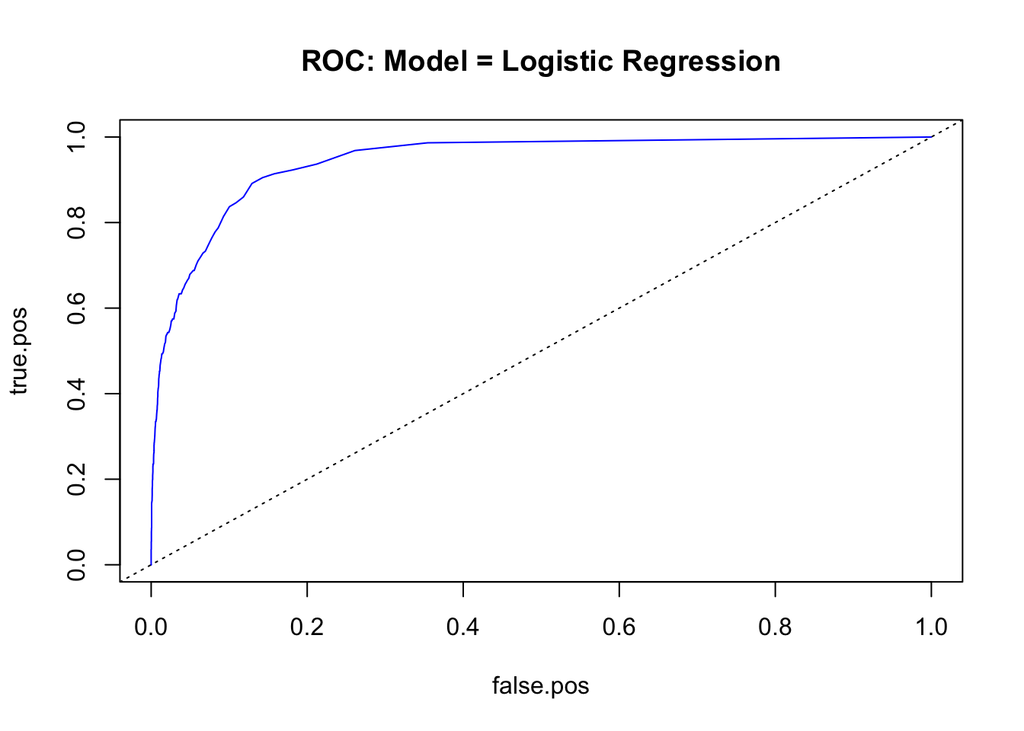

```
## AUC: 0.9515385
## The optimal threshold based on minimum 0-1 loss: 0.46 0.475 0.48
```

| auc | optimal.thres |
| --- | --- |
| 0.9515385 | 0.460 |
| 0.9515385 | 0.475 |
| 0.9515385 | 0.480 |

```r
ROC.logistic(model = glm.fit, data = train.data)
```

```r
cat("Test Data:")
```

```
## Test Data:
```

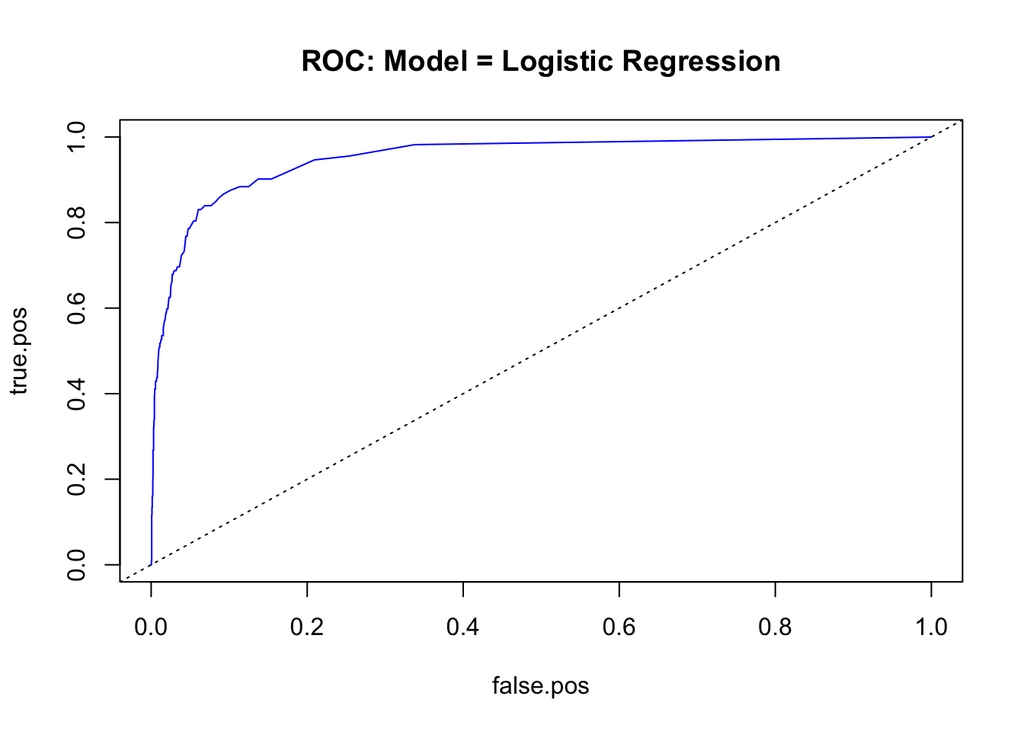

```
## AUC: 0.9596545
## The optimal threshold based on minimum 0-1 loss: 0.48 0.485
```

| auc | optimal.thres |
| --- | --- |
| 0.9596545 | 0.480 |
| 0.9596545 | 0.485 |

```r
ROC.logistic(model = glm.fit, data = test.data)
```

4. Compute the test error for the $p=.5$ threshold versus the optimal threshold based on the test data. How do they compare? Should the analyst change the threshold from .5?

```r
ans <- ROC.logistic(model = glm.fit, data = test.data)
```

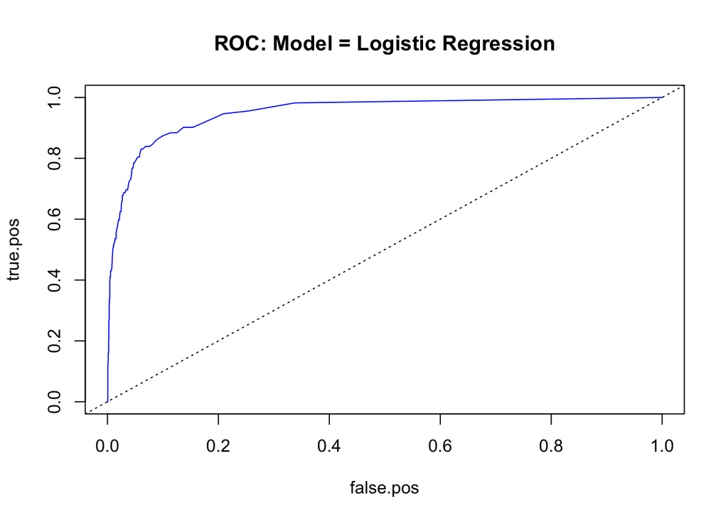

```
## AUC: 0.9596545
## The optimal threshold based on minimum 0-1 loss: 0.48 0.485
```

```r
#test error p=0.5
test.data.new <- test.data %>% add_predictions(model = glm.fit, var = "pred") %>%
  mutate(sigmoid.pred = sigmoid(pred)) %>% mutate(glm.pred_0.5 = ifelse(sigmoid.pred>0.5,1,0),
                                                  glm.pred_1 = ifelse(sigmoid.pred>ans$optimal.thres[1],1,0),
                                                  glm.pred_2 = ifelse(sigmoid.pred>ans$optimal.thres[2],1,0))
test.data.new <- as_tibble(test.data.new)

cat("Threshold p = 0.5, Test Error:", sum(test.data.new$default != test.data.new$glm.pred_0.5) / nrow(test.data.new))
```

```
## Threshold p = 0.5, Test Error: 0.02666667
```

```r
cat("Threshold p =", ans$optimal.thres[1], ", Test Error:", sum(test.data.new$default != test.data.new$glm.pred_1) / nrow(test.data.new))
```

```
## Threshold p = 0.48 , Test Error: 0.02633333
```

```r
cat("Threshold p =", ans$optimal.thres[2], ", Test Error:", sum(test.data.new$default != test.data.new$glm.pred_2) / nrow(test.data.new))
```

```
## Threshold p = 0.485 , Test Error: 0.02633333
```

```
## Based on the test data, the optimal thresholds derived from the 0-1 loss have lower error rate compared to that of setting threshold as 0.5.
## The error rate would reduce from 0.02666667 to 0.02633333 if one uses the optimal thresholds insead of 0.5. But the difference is considered to be pretty small. Therefore, using p = 0.5 as the threshold is still acceptable in this case.
```